```
output:
  bookdown::pdf_document2:
    fig_caption: yes
    toc: TRUE
    toc_depth: 3
    fontsize: 12pt
    latex_engine: xelatex
bibliography: "Bachelor_quellen.bib"
biblio-style: apalike
citation_package: biblatex
link-citations: yes
urlcolor: RoyalBlue
linkcolor: RoyalBlue
header-includes:
  \usepackage{float}
  \usepackage[ngerman]{babel}
  \usepackage[onehalfspacing]{setspace}
  \usepackage[utf8]{inputenc}
  \usepackage{xcolor}

---
```

# Diskussion

Influenza Viren sind eine der bedeutendsten viralen Atemwegs-Infektionserkrankungen mit mehr als 300.000 jährlichen Todesfällen weltweit. Die Antivirale Therapie unterliegt einer starken Zeitanhängigkeit und muss spezifisch für die verschiedenen Subtypen angepasst werden, was eine frühzeitige Detektion für den Behandlungserfolg unerlässlich macht.  
Ziel der Arbeit ist es jeweils ein RT-RPA Nachweissystem zur Detektion der Influenza A und B Viren für die Point-of-care Diagnostik zu Entwickeln und dieses zu Optimieren. Zusätzlich sollte der Einfluss einer Primerasymmetrie und verschiedener Sondenmodifikationen auf die RT-RPA untersucht werden.  
Es konnten RT-RPA’s für die Detektion der Influenza A und B Viren entwickelt werden, wobei die Influenza B RT-RPA als Pan-Influenza B Nachweis dient und die Influenza A RT-RPA die Subtypen H1N1 und H3N2 Detektieren kann. Des Weiteren konnte ein positiver Effekt einer Primerasymmetrie auf die RPA festgestellt werden, welcher jedoch im Zusammenhang mit der Hybridisierungsposition der Sonde steht. Ebenfalls konnte anhand der Influenza A RT-RPA ein Einfluss des Sondendesings hinsichtlich *dt-Quenched* und *internally Quenched* festgestellt werden, wobei die *dt-Quenched* Sonde zu einer erhöhten Sensitivität im Vergleich zu der *internally Quenched* Sonde führt.

## Design der Primer und deren Einfluss auf die RT-RPA

Bei der Wahl des Amplifikationsbereiches für die Influenza B RT-RPA wurde sich für das Genomsegment 8 entschieden. Dabei wurde sich an der Literatur von RT-PCR Systemen orientiert [@Goffard2008; @NCIRD2021]. Da bei Influenza B im Gegensatz zu Influenza A eine geringere Mutationsrate vorliegt und zusätzlich keine großen Antigenen Veränderungen der Oberflächenproteine beobachtet wurden [@Chen2008; @Paterson2003] konnten wie in Kapitel @ref(desing) angegeben keine Differenzen zwischen verschiedenen Stämmen in dem entsprechenden Genomsegment festgestellt werden. Dementsprechend kann davon ausgegangen werden, dass der gewählte Amplifikationsbereich geeignet ist alle Viruslinien zu Detektieren.  
Als Amplifikationsbereich für die Influenza A RT-RPA wurde das M1-Gen auf dem Genomsegment 7 gewählt, da es durch seine Funktion das am stärksten Konservierte Gen ist [@McCauley1983]. Zusätzlich wurde sich an der Literatur für RT-PCR Systeme orientiert welche ebenfalls das M1-Gen zur Detektion Amplifizieren [@Daum2007; @Suwannakarn2008; @NCIRD2021]. Trotz der Konserviertheit des Gens besitzt das Alignement zwischen den Subtypen H1N1 und H3N2 etliche Basenfehlpaarungen, wobei die größte Homologie im Bereich zwischen 10 bp und 250 bp zu beobachten ist (siehe Abbildung @ref(fig:infAalign)). Aus diesem Grund befinden sich alle vom PrimedRPA designten und von @Ehnts2013 entwickelten Primer (siehe Tabelle @ref(tab:infaoligo)) in diesem Bereich.

(ref:alingmentinfa) **Alignment zwischen den Influenza A H1N1- und H3N2-Subtyp:** Alignement des Genomsegmentes 7 zwischen dem H1N1-Subtyp und dem H3N2-Subtyp. Der unterste Balken gibt die Sequenzlänge in bp an. Die roten Striche stehen für Basenfehlpaarungen zwischen den beiden Genomsegmenten. Der orange markierte Bereich gibt den Sequenzabschnitt mit der größten Homologie an.

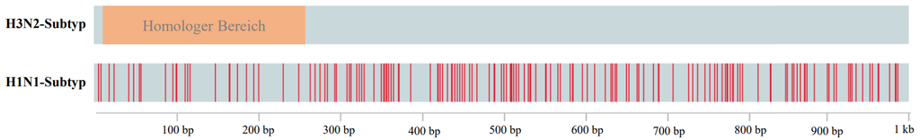

(ref:alingmentinfa)

Um die Basenfehlpaarungen auszugleichen, wurden wie in Kapitel @ref(desing) degenerierte Basen in den Primern und Sonden eingeführt, welche die Hybridisierung erleichtern und somit die Amplifikation verbessern [@Linhart2005]. Einen anderen Ansatz verfolgte @Liang2022, welcher zur Detektion der beiden Subtypen innerhalb einer RT-RPA zwei verschiedene Genomsegmente wählte [@Liang2022]. Dies hat jedoch den Nachteil, dass @Liang2022 zwei getrennte Reaktionen zum Nachweis der Influenza A Viren benötig, während die in dieser Arbeit entwickelte Influenza A RT-RPA nur eine Reaktion für ein aussagekräftiges Ergebnis erfordert.

Wie in Abbildung @ref(fig:infAsadsensi) zu erkennen ist, sind die vom PrimedRPA Programm designten Primer für das Influenza A Virus aufgrund ihrer niedrigen Fluoreszenz und ihres späten Anstiegs unfunktionell. Betrachtet man hingegen das Primerscreening für die Influenza B RT-RPA (siehe Abbildung @ref(fig:infbscreening)) zeigen alle entwickelten Primer-Sonden-Kombination eine Amplifikation und sind theoretisch funktionell. Somit ist eine deutliche Differenz hinsichtlich der Funktionalität des PrimedRPA Programms für die Entwicklung von Primer-Sonden-Kombinationen zu beobachten. Dies könnte an den verwendeten Sequenzvorlagen liegen, da bei Influenza A im Gegensatz zu Influenza B zwei nicht vollständig Homologe Sequenzen als Vorlage verwendet wurden. Dies führte dazu, dass die entwickelten Primer und Sonden bis zu 3 Basenfehlpaarungen je nach Subtyp aufweisen. Jedoch konnte in der Literatur gezeigt werden, dass bis zu 6 Fehlpaarungen in den Primer die RPA nicht unfunktionell werden lassen [@Boyle2013]. Des Weiteren wurde durch @Higgins2022 und @Daher2015 gezeigt, dass vor allem Missmatches am 3’ und 5’-Ende des Primers die RPA inhibieren, welche nur bei dem Forward 1 Primer auftrat und durch eine degenerierte Base teilweise vermieden wurde [@Higgins2022; @Daher2015]. Interessanterweise besitzt das von @Ehnts2013 entwickelte RPA-System am 3’-Ende eine Basenfehlpaarung, welche ebenfalls durch eine degenerierte Base ausgeglichen wurde. Jedoch besitzt diese Primer-Sonden-Kombination von allen getestet Kombinationen die beste Amplifikation. Durch die alternativen forward Primer (E.2 und E.3) wurde versucht, diese Fehlpaarung zu gänzlich zu vermeiden, jedoch liegt die Amplifikation nahezu gleich bzw. leicht hinter den von @Ehnts2013 entwickelten Primern und Sonde. Dies Spricht gegen die Beobachtungen @Higgins2022 und @Daher2015 jedoch wurden in den beiden Studien nur Fehlpaarungen in den Primer untersucht [@Higgins2022; @Daher2015]. @Liu2019 konnte zeigen, dass Missmatches in der Sonde zu einer vollständigen Inhibierung und sogar zu falsch positiven Amplifikationen der RPA führen können [@Liu2019]. Das könnte eine Erklärung zur großen Diskrepanz, zwischen dem von @Ehnts2013 entwickelten RPA-System und dem mit PrimedRPA designten Primer-Sonden-Kombinationen sein. Eventuell führt die Verteilung der Basenfehlpaarungen in den PrimedRPA-Sonden zu einer unfunktionellen RT-RPA während die von @Ehnts2013 entworfene Sonde nur bedingt inhibierende Fehlpaarungen aufweist. Des Weiteren ist bei dem Primerscreening der Influenza B RT-RPA (siehe Abbildung @ref(fig:infbscreening)) am Beispiel der beiden getesteten Sonden zu erkennen, dass nicht nur Basenfehlpaarungen sondern auch andere Einflüsse zu unterschiedlicher RPA-Performance führen. So kann Einerseits die Hybridisierungsposition der Sonde im gleichen Amplifikationsbereich zu einer signifikanten Veränderung der Amplifikation führen [@Liu2019]. Andererseits kann die zu detektierende RNA, durch Bildung von Sekundärstrukturen die Amplifikation behindern [@Saisuk2019]. So konnte Beispielweise @Wei2003 innerhalb einer PCR zeigen, dass eine RNA-Sekundärstruktur trotz der hohen Temperaturen in der PCR die Amplifikation inhibierte [@Wei2003].  
Betrachtet man die Hybridisierungsposition, der für die Influenza A RT-RPA entwickelten Primer und Sonden liegen diese am Anfang der der Genomsequenz bei ~50 bp bis ~ 200 bp (siehe Tabelle @ref(tab:infaoligo)). Wie in Kapitel @ref(InfAeinleitung) erwähnt sind die jeweiligen Enden eines Genomsegmentes komplementär zueinander und bilden im Virion eine Loop-Struktur aus [@Modrow2010]. Somit kann diese Loop-Struktur *in vitro* eventuell die Amplifikation der Influenza A RT-RPA inhibieren, da der Amplifikationsbereich am Anfang der Genomseqeunz liegt. Damit lässt sich der Unterschied zwischen der Influenza A RT-RPA und der Influenza B RT-RPA erklären, da bei der Influenza B RT-RPA der Amplifikationsbereich mittig in der Genomsequenz zwischen ~650 bp und ~730 bp liegt und ist somit von der Loop-Struktur nicht beeinflusst wird.

[output not shown]

## Vorteile der low-Volume RPA hinsichtlich Mischzeitpunkt und Sensitivität

Wie in @ref(rpa) erwähnt kommt es, während der RPA durch geringe Thermische Konfektion und durch den crowding Agent erschwerte Diffusion zu lokaler Reagenzien-Knappheit. Um dem entgegen zu wirken, wird ein zusätzlicher Mischschritt während der Reaktion durchgeführt, welcher zu einer erneuten Homogenisierung der Reaktion führt [@Lillis2016]. @Lillis2016 konnte jedoch zeigen, dass eine Reduktion des Reaktionsvolumens auf 5 µl die Notwendigkeit des zusätzlichen Mischschrittes minimiert [@Lillis2016]. Wie in @ref(infboptimierung) gezeigt, konnte ein ähnliches Verhalten mit der low-Volume RPA anhand der Influenza B RT-RPA beobachtet werden. Hier wurde das Reaktionsvolumen auf 6,5 µl angepasst was einem leicht höheren Volumen als dem von @Lillis2016 entspricht. Jedoch stellt sich im Vergleich zwischen den Mischzeiten des 50 µl Ansatzes und der low-volume RPA heraus, dass der Mischschritt bei der low-volume RPA erst einen deutlichen Einfluss bei 10<sup>1</sup> RNA-Kopien ausübt (siehe Abbildung @ref(fig:infboptimisch)) und die maximale Fluoreszenz und die Anzahl der positiven Amplifikationen deutlich verbessert. Im 50 µl Ansatz hingegen kann schon eine deutliche Verbesserung der Fluoreszenz und eine große Verbesserung des TT-Wertes bei 10<sup>4</sup> RNA-Kopien beobachtet werden. Diese Beobachtung stimmen mit den von @Lillis2016 überein. Eine mögliche Begründung liegt darin, dass einerseits durch das verringerte Volumen ein größeres Verhältnis zwischen hinzugefügter Probe und Reaktionsmix besteht und dadurch eine bessere Diffusion zwischen den beiden Komponenten stattfindet. Andererseits führt das geringere Volumen zu einem größeren Oberflächen-Volumen Verhältnis, welches zu einer besseren Wärmeübertragung und dementsprechend einer stärkeren Konvektion führt [@Boeckh2017].  
Des Weiteren konnte anhand der Influenza B RT-RPA beobachtet werden, dass eine Reduktion des Reaktionsvolumens zu einer deutlichen Sensitivitätserhöhung von über 50 % führt. Der gleiche Effekt konnte, wenn auch nicht so stark konnte ebenfalls durch @Lillis2016 nachgewiesen werden. Ob es sich hierbei um eine signifikante Änderung handelt, muss in einer weiteren Versuchsreihe bestätigt werden, da das Detektionslimit in dieser Arbeit für den 50 µl Ansatz nur in Dreifachbestimmung durchgeführt wurde. Dieses Phänomen der Sensitivitätsverbesserung lässt sich ebenfalls durch das erhöhte Verhältnis zwischen eingesetzter Probe und RPA-Reaktion und der erhöhten Konvektion erklären.  
Zusätzlich bietet die low-volume RPA den Vorteil der Kostenreduzierung, da aus einer kommerziell erhältlichen Reaktion acht Tests durchgeführt werden können (siehe @ref(8telRPA)). Dies macht die low-volume RPA gerade für Ressourcen limitierte Umgebungen attraktiv, da sie geringe Kosten pro Test zusammen mit einfacher Handhabung, durch die gesteigerte Unabhängigkeit des Mischschrittes, hoher Sensitivität sowie robusten Reagenzien [@Lillis2016] kombiniert [@Jiang2021].  
Durch das verringerte Reaktionsvolumen von 6,5 µl eignet sich die low-Volume RPA für den Einsatz in der Mikrofluidik, wo sie mit 3D-gedruckten Detektionschips kombiniert werden kann [@Behrmann2020b]. Dadurch erweitern sich ihre Applikationsmöglichkeiten in der POCT und Testsysteme können vereinfacht und verbessert werden [@Behrmann2020].  
Es konnte beobachtet werden, dass große Mengen an DNA die RPA inhibieren [@Li2019; @Rohrman2015] und diese Inhibierung konzentrationsabhängig von der DNA-Konzentration ist [@Clancy2015]. Dies könnte die low-volume RPA einschränken, da durch das erhöhte Proben/RPA-Verhältnis auch die Konzentration von humaner Hintergrund-DNA steigt und somit die RPA inhibiert. Zusätzlich konnten die positiven Effekte der low-Volume RPA nur anhand der Influenza B RT-RPA beobachtet werden. Eine Adaption an die low-volume RPA für die Influenza A RT-RPA konnte durch die höheren TT-Werte und linearen Amplifikationsverlauf, welcher auf eine schlechte Kinetik deutet, da keine exponentielle Amplifikation mehr vorliegt, nicht erreicht werden. Dementsprechend lässt sich sagen, dass die low-volume RPA nicht für alle RPA-Assays adaptierbar ist und somit die Applikation eingeschränkt wird. Des Weiteren wurde eine Verringerung des Reaktionsvolumens nur bei RNA-Viren beschrieben [@Lillis2016; @Behrmann2020], wodurch eine Adaption auf DNA basierte RPA’s noch unklar ist.

## Vergleich der ermittelten Sensitivitäten mit PCR-Assays

Wie in Kapitel @ref(infbsense) beschrieben liegt das Detektionslimit der optimierten low-Volume RT-RPA für den Influenza B Virus bei 14,6 RNA-Kopien. Im Vergleich zu der getesteten RT-PCR vom @NCIRD2021 konnte eine Differenz von nur 3 Kopien festgestellt werden, wobei die Unterschiede im Konzentrations-Bereich von $2*10^0$ RNA-Kopien liegen. In diesen Sensitivitätsbereich spielt einerseits die zufällige Diffusion eine Rolle, welche bestimmt ob die einzelnen Reaktionskomponenten miteinander Interagieren sowie minimale Ungenauigkeiten bei der Verdünnung der RNA-standards, welche dazu führen, dass keine Nachweisbaren RNA-Kopien in dem eingesetzten Probenvolumen enthalten sind. Andererseits zeigen Nukleinsäuren eine Adsorption an die verwendeten Polypropylen-Tubes [@Zandieh_2022], welches sie für die RPA-Reaktion unzugänglich machen und gerade bei geringen Kopienzahlen einen Einfluss haben. Veranschaulicht werden diese Effekte in Abbildung @ref(fig:infboptimisch)D. Hier zeigt eine Messung, bei welcher durch zufällige Diffusion die Reaktionskomponenten miteinander interagieren konnten, einen deutlichen Anstieg, während alle anderen Messungen keine Signalveränderung aufweisen. Dementsprechend lässt sich sagen, dass die entwickelte RT-RPA für das Influenza B Virus der PCR als Goldstandard ebenbürtig ist. Bei dem Sensitivitätsvergleich mit der Literatur liegt das Detektionslimit der RT-RPA ebenfalls leicht unter dem von vergleichbaren PCR-Systemen [@Ni_2021; @Shu_2020; @Wu_2008] und ähnlich wie ein RPA-Vergleichssystem [@Liang2022].  
Das Detektionslimit der optimierten Influenza A RT-RPA liegt im Gegensatz zur Influenza B RT-RPA weit hinter der Sensitivität der getesteten RT-PCR (siehe Tabelle @ref(tab:infasensver)) und rund 10-100 mal über den Detektionslimits von PCR- und RPA-Assays in der Literatur [@Wu_2008; @Ni_2021; @Liang2022]. Das vergleichsweise hohe Detektionslimit der Influenza A RT-RPA lässt sich wie in @ref(dissdesign) diskutiert durch die erhöhte Anzahl an Basenfehlpaarungen in Primern und Sonde sowie eventuelle Bildung von Sekundärstrukturen erklären.  
Wird das Detektionslimit in simulierten Kontrollproben für die Influenza A und B RT-RPA betrachtet fällt auf, dass es in Influenza B zu einer deutlichen Verschlechterung des Detektionslimits kommt (siehe Tabelle @ref(tab:infbsensver)), während Influenza A scheinbar keine Beeinflussung erfährt (siehe Tabelle @ref(tab:infasensver)). Dieses Phänomen könnte an den unterschiedlichen Reaktionsvolumen der verschiedenen RPA-Assays zusammen mit dem eingeführten humanen Hintergrund liegen. Wie in @ref(disslowrpa) erwähnt, können große Mengen an genomischer DNA die RPA inhibieren. Dabei hänge die Inhibierung neben der Konzentration der genomischen DNA auch von der Konzentration des eingesetzten zu amplifizierenden Materials ab [@Rohrman2015]. Da das verwendete QiAamp Viral RNA Mini Kits zum Erhalt des humanen Probenhintergrunds keinen DNAse-Verdau Schritt durchführt (siehe unten @ref(klinischeproben)) bleibt die genomische DNA in den Extrakten erhalten. Dementsprechend könnte durch das höhere Proben-Reaktion-Verhältnis im low-volume Ansatz schon geringere Mengen an genomischer DNA bei niedrigen Konzentrationen die beobachtete Inhibierung zur Folge haben, während der 50 µl Ansatz durch sein höheres Volumen keine Inhibierung aufweist. Der Arbeit von @Rohrman2015 zufolge sorgt eine DNA-konzentration von 500 ng bei Template-Konzentrationen von 10<sup>2</sup> Kopien für eine komplette Inhibierung der RPA. Rechnet man die Konzentration der genomischen DNA auf den low-volume Ansatz runter, würden 62,5 ng ausreichen, um eine vollständige Inhibierung auszulösen. Die ermittelte Konzentration der Kontrollproben liegt bei rund 45 ng/µl (siehe Kapitel @ref(infbsense)) und somit in einem ähnlichen Konzentrationsbereich. Zusätzlich sorgt das erhöhte Proben-Reaktion-Verhältnis zu einem höheren genomischen DNA-Verhältnis im Vergleich zur RPA-Reaktion was die benötigte Konzentration zur Inhibierung abermals Senkt. Dementsprechend ist eine Inhibierung der RPA im low-volume Ansatz bei niedrigen Kopien-Anzahlen plausibel.  
Eine mögliche Erklärung für die Inhibierung der RPA bei hohen DNA-Konzentrationen könnten dabei bei illegitimen Primer- oder Sonden-Hybridisierungen liegen. Durch die vergleichsweise niedrige Temperatur der RPA können Fehlbildungen der Primer und Sonden an die genomische DNA vorkommen, wodurch sie für die eigentliche Reaktion nicht mehr zur Verfügung stehen. Dieser Effekt würde dabei stark von der Konzentration der Ziel-DNA abhängig sein, da höhere Template-Konzentrationen bei gleichbleibenden genomischen Hintergrund zu einer höheren Wahrscheinlichkeit für eine spezifische Primer-Bindung führen. Um dem entgegenzuwirken, müsste die genomische Hintergrund-DNA Verhältnismäßig erhöhte werden um die Wahrscheinlichkeit für spezifische Bindungen zu reduzieren. Diese Verhältnismäßigkeit wurde von @Rohrman2015 beobachtet, welches die Hypothese bekräftigt. Jedoch konnte zum Zeitpunkt der vorliegenden Arbeit keine Bestätigung der Hypothese in der Literatur gefunden werden. Eine Erhöhung der Primer- bzw. Sonden-Konzentration könnte für spezifischere Bindungen und somit bessere Amplifikation auch in hohen genomischen DNA-Konzentration sorgen, jedoch müsst dies in einer weiteren Versuchsreihe untersucht werden und war nicht Teil dieser Arbeit.  
Die in der Literatur beschrieben Viruslasten für die Influenza A Subtypen liegen bei bei allen Altersgruppen im Mittelwert bei rund 10<sup>3,5</sup> Virus Kopien/µl (H1N1) und 10<sup>3,3</sup> Virus Kopien/µl (H3N2) [@Rodrigues_Guimar_es_Alves_2020; @Ngaosuwankul2010] wobei eine Ausnahme die Patientengruppe unter zwei Jahren mit 10<sup>2,67</sup> Virus Kopien/µl (H1N1) bildet [@Rodrigues_Guimar_es_Alves_2020]. Die beste Entnahmemethode sind dabei Nasopharyngeal-Abstriche, welche im Durchschnitt 10<sup>5,0</sup> Virus Kopien/µl Enthalten, während Nasal-Abstriche mit 10<sup>3,8</sup> Virus Kopien/µl und Rachen-Abstriche mit 10<sup>3,4</sup> Virus Kopien/µl deutlich geringere Viruslasten aufweisen [@Ngaosuwankul2010]. Die für die Influenza A ermittelte Sensitivität in den simulierten Kontrollproben kann mit einem Detektionslimit von 147,5 RNA-Kopien für beide Subtypen (siehe Tabelle @ref(tab:infasensver)) im Durschnitt alle Patientenproben nachweisen. Eventuelle Komplikationen könnten bei Patienten unter zwei Jahren aufkommen, da die Viruslast nahe an der Detektionsgrenze liegt. Für eine sichere Detektion ist generell ein Nasopharyngeal-Abstrich durchzuführen, da hier im Durchschnitt die größte Viruslast erlangt wird und somit ein eventuelle Annährung an das Detektionslimit vermieden werden kann. Für Influenza B konnte in einer Studie von @Rodrigues_Guimar_es_Alves_2019 eine durchschnittliche Viruslast in allen Altersgruppen von rund 10<sup>3,5</sup> Virus Kopien/µl festgestellt werden. Ausnahme bildeten dabei Patienten über 59 Jahren, da hier nur ein Datensatz verfügbar war und somit keine einheitliche Aussage getätigt werden kann [@Rodrigues_Guimar_es_Alves_2019]. Eine andere Studie von @Tsou_2012 untersuchte die Viruslast speziell bei Kindern und konnte im Durschnitt sehr geringe Werte von Durchschnittlich 3,9 Virus Kopien/µl feststellen. Jedoch wurden innerhalb dieser Studie große Schwankungen innerhalb der Viruslast festgestellt (zwischen $45$ und $2*10^6$ Virus Kopien/ml) sowie eine negative Korrelation zwischen Viruslast und Zeitpunkt der Probenentnahme [@Tsou_2012]. Das mit der reinen, artifiziellen Standard RNA ermittelte Detektionslimit für die Influenza B RT-RPA wäre mit 14,6 RNA-Kopien (siehe Tabelle @ref(tab:infbsensver)) in der Lage die meisten Patientenproben zu detektieren. Betrachtet man jedoch den starken Verlust der Sensitivität bei den simulierten Kontrollproben können Komplikationen gerade bei Kinderpatienten auftreten. Hier liegt das ermittelte Detektionslimit von 1397 RNA-Kopien (siehe Tabelle @ref(tab:infbsensver)) weit über der von @Tsou_2012 ermittelten Viruslast. Nach @Rodrigues_Guimar_es_Alves_2019 könnten zwar alle Patienten inklusive Patienten unter zwei Jahren im Durchschnitt detektiert werden, jedoch befindet sich hier die Viruslast nahe am Detektionslimit. Generell lässt sich sagen, dass die entwickelte Influenza B RT-RPA ein zu hohes Detektionslimit besitzt um zuverlässig Influenza B Detektieren zu können. Eine eventuelle Verbesserung des Detektionslimits in einem humanen DNA-Hintergrund könnte durch die Verwendung des 50 µl Ansatzes oder durch die Erhöhung der Primer- oder Sonden-Konzentration erreicht werden, jedoch müsste dies in weiteren Versuchen bestätigt werden. Zusätzlich sollte, um eine möglichst zuverlässige Detektion zu ermöglichen eine zeitnahe Proben Entnahme erfolgen, um möglichst hohe Viruslasten zu erreichen [@Tsou_2012].

## Entwicklung der asymmetrischen *real time* RT-RPA

Wie den Kapiteln @ref(infboptimierung) und @ref(infbassymet) festgestellt, führt eine asymmetrische Erhöhung des reverse Primer zu einer erhöhten Fluoreszenz, wobei die Verteilung der Primer-Asymmetrie von der Hybridisierungsposition der Sonde (sense- oder antisense-Strang) abhängt. Wie in Kapitel @ref(assymetrie) beschrieben sorgt die ungleiche Verteilung der Primer dazu, dass im Verlauf der Reaktion einzelsträngige DNA entsteht. Dabei wurde die asymmetrische Primerverteilung innerhalb der RPA von @Wang_2019 beschrieben um *Fusarium proliferatum* mittels eines enzymkatalysiertem Farbumschlags nachzuweisen [@Wang_2019]. @Sollweck_2021 kombinierte die asymmetrische RPA um mit der entstandenen einzelsträngigen DNA ein Nachweis mittels Microarry durchzuführen [@Sollweck_2021]. Derzeit ist die Verwendung einer asymmetrischen Primerverteilung in Kombination mit fluoreszenzmarkierten Sonden in der Literatur nur innerhalb der qPCR bekannt. So konnte @Poddar2000 mithilfe von Molecuar Beacons nachweisen, dass durch die Primerasymmetrie die zur Sonde komplementäre DNA-Sequenz zusätzlich als einzelsträngige DNA und somit vermehrt vorliegt. Dadurch konnten die Molecular Beacons häufiger hybridisieren und somit ein stärkeres Fluoreszenzsignal erzeugen [@Poddar2000]. In der hier vorliegenden Arbeit konnte gezeigt werden, dass das von @Poddar2000 beschriebene Prinzip auf die RPA mittels Exo-Sonden anwendbar ist. Dies wurde über die Experimente in Kapitel @ref(infbassymet) bestätigt. Durch die Erhöhung des Forward Primer (siehe Abbildung @ref(fig:assymetriy)A) wurde die Asymmetrie wieder angeglichen, wodurch ein Rückgang an Fluoreszenz beobachtet werden konnte. Das beweist, dass die Asymmetrie mit der Fluoreszenzerhöhung zusammenhängt. Des Weiteren konnte gezeigt werden, dass die Hybridisierungsposition der Sonde mit der Primer-Asymmetrie zusammenhängt (siehe Abbildung @ref(fig:assymetriy)B). Daraus lässt schließend, dass durch die Primerasymmetrie, die zur Exo-Sonde komplementäre DNA-Sequenz häufiger Amplifiziert wird, wodurch die Sonde an die entstandene einzelstränge DNA hybridisiert und von der Exonuclease gespalten wird. Dadurch wird mehr Sonde als bei einer Konventionellen RPA gespalten, wodurch mehr Fluoreszenzsignal detektierbar wird. Dieses Prinzip konnte ebenfalls auf die Influenza A RT-RPA übertragen werden, was beweist, dass die Asymmetrie nicht nur speziell Anhand der Influenza B RT-RPA nachweisbar ist, sondern allgemeiner angewandt werden kann. Jedoch wurde dieses Prinzip in dieser Arbeit nur anhand der RT-RPA nachgewiesen. Eine Adaption auf eine DNA basierte RPA müsste noch untersucht werden, um allgemeingültige Aussagen treffen zu können.

## Einfluss der Exo-Sondenmodifikation auf die RT-RPA

Die Sondenmodifikation innerhalb der RPA hinsichtlich Fluorophor- und Quencher-Position unterliegt Sequenz-Limitationen. So ist eine Kopplung des Fluorophors beziehungsweise des Quenchers an die Purin-Basen (Adenin A, Guanin G) ungünstig, da die Kopplung an der 8’-Position erfolgt und so das Nukleosid in eine Synkonformation gezwungen wird. Dadurch kommt es zu einer Störung der Watsen und Crick Basenpaarung, was die Hybridisation erschwert [@Wagenknecht_2008]. Eine Kopplung an die Purin-Basen (Cytosin C, Thymin T) ist vorzuziehen, da es hier zu einer geringeren Beeinträchtigung kommt. Hierbei erfolgt die Kopplung an die 5’-Position, wodurch die Konformation des Nukleosids weitestgehend nicht beeinträchtigt wird. Sterischen Behinderungen zwischen Fluorophor und DNA können jedoch bei beiden Kopplungspositionen nicht ausgeschlossen werden [@Wagenknecht_2008]. Der Stand der Technik beschränkt und sich dabei auf T-gekoppelte Quencher und Sonden [@Faye2021; @Guo_2022; @TwistDx2018]. Da der FRET-Mechanismus zur Detektion des Fluoreszenzsignales sehr stark von der Distanz zwischen Quencher und Fluorophor abhängig ist [@Johansson_2003] benötigt die Sondensequenz dementsprechend zwei dicht nebeneinander liegende T Basen. zusätzlich werden die Anforderungen an die Sondensequenz noch durch die a-basische Seite, welche von der Exonuklease gespalten wird und der Fluorophorposition, welche bei rund 30+ bp liegen sollte [@Lobato2018] erschwert. So benötigt die Sonde bei rund 30 bp eine T-X-T Sequenz (X = beliebiges Nukleotid), wodurch die Sondenposition in den meisten Fällen deutlich eingeschränkt wird. Um diesem Problem zu entgehen entwickelten @Behrmann2020 die *internally quenched* Sonde, bei welcher der Quencher an das Phosphat-Rückgrat der DNA gekoppelt wird (siehe Kapitel @ref(modifikation)) und so die starke Abhängigkeit der T-X-T Sequenz umgangen wird. Somit können Exo-Sonden variabler an die Zielsequenz angepasst werden [@Behrmann2020]. In dieser Arbeit konnten deutliche Unterschiede zwischen den beiden Sondentypen ermittelt werden (siehe Abbildung @ref(fig:infasondenopti)) So führt die *dT-Quenched* Sonde zu einer höheren Sensitivität und zu einem niedrigeren Hintergrundsignal. Eine mögliche Hypothese für diese Beobachtung könnte im Zusammenhand mit der verwendeten Primer-Asymmetrie liegen. Durch die eingeführte Primer-Asymmetrie liegt der zur Sonde komplementäre DNA-Strang einzelsträngig vor. Dementsprechend kann die Sonde unabhängig von der Strangverdrängungsaktivität der Polymerase hybridisieren. Nach der Spaltung durch die Exonuklease findet keine Verdrängung durch die Polymerase statt und die Sonden-Fragmente müssen sich durch Diffusion voneinander trennen. Durch den dT gekoppelten Quencher besteht im hybridisierten Zustand der Sonde eine sterische Abstoßung zwischen Quecher, Fluorophor und gegenüberliegender A Base. Bei der Spaltung der Sonde sorgt diese sterische Abstoßung für eine bessere Diffusion des Quenchers von dem Fluorophor was zu einem erhöhtem Signal führt. Im Gegensatz dazu entsteht bei der von @Behrmann2020 entwickelten *internally quenched* Sonde keine solche Abstoßung, da der Quencher über das Phosphat-Zucker-Rückgrat der DNA gekoppelt ist und somit außerhalb der Doppelhelix ragt. Betrachtet man die mittlere Schmelztemperatur (Tm) des Sonden-Fragments mit dem Quencher liegt diese bei 53 °C (berechnet online[^1]). Dementsprechend würde nach der Spaltung der Sonde die Diffusion des Quencher-Fragments ohne weitere Abstoßungseffekte bei der gewählten Reaktionstemperatur von 42 °C deutlich erschwert werden. Das beobachtete geringere Signal-Rauschen der Negativkontrolle der *dT-Quenched* Sonde lässt sich auf den erhöhten Abstand zwischen Fluorophor und Quencher zurückführen. Wie in der von @F_rster_1948 entwickelten Formel zu sehen, ist die Energie-Übertragungsrate ($F_{ kl }$) von der Fluoreszenzabklingzeit ($\tau_{ 0 }$), dem Förster-Radius ($R_{ 0 }$) und dem Abstand zwischen Fluorophor und Quencher ($R_{ kl }$) abhängig (siehe Formel @ref(eq:sieben)). $R_{ 0 }$ ist dabei für verschiedene Fluorophorpaare unterschiedlich und wird zur Vereinfachung $R_{ 0 }=1$ gesetzt [@F_rster_1948]. Dadurch wird die sehr starke Abhängigkeit von dem Abstand zwischen Fluorophor und Quencher deutlich. Dementsprechend können kleine Veränderungen des Abstandes zu einem deutlich schlechteren Energietransfer, also zu einem schlechteren Fluoreszenz-Quenching führen. Da die *dT-Quenched* Sonde durch die dT-Kopplung von Fluorophor und Quencher beide Moleküle näher zusammenbringt als es bei der *internally quenched* Sonde der Fall ist, findet demnach eine besseres Quenching des Fluoreszenzsignals statt. Dieses drückt sich in dem in Abbildung @ref(fig:infasondenopti) beobachteten geringeren Hintergrund-Signal aus.

```
\begin{equation}
F_{ kl }=\frac{ {R_{ 0 }}^{ 6 } }{\tau_{ 0 } * {R_{ kl }}^{ 6 } } \; \; \; \; \; \; \; mit \; \; \; \; R_{ 0 } =1 \; \; \; \; \; \; \; F_{ kl }=\frac{ 1 }{\tau_{ 0 } * {R_{ kl }}^{ 6 } }
(\#eq:sieben)
\end{equation}
```

## Das Ditching innerhalb der RT-RPA

Die spontane Abnahme des Fluoreszenzsignals im späteren Verlauf der Messung konnte an mehreren Stellen dieser Arbeit beobachtet werden (siehe Abbildungen @ref(fig:infbopti), @ref(fig:infboptimisch)B, @ref(fig:assymetriy)A, @ref(fig:infbsensi)B, @ref(fig:infaopti)B). Dabei scheint dieses Phänomen speziell innerhalb der RPA aufzutreten und wurde weder innerhalb der PCR, noch innerhalb anderen isothermen Amplifikationen (LAMP, NASBA etc.) beobachtet. @Lutz2010 beschrieben dieses Phänomen innerhalb der RPA als Ditching, lieferten jedoch keine weiteren Erklärungen zu dem Sachverhalt [@Lutz2010]. Das Ditching widerspricht dabei dem theoretisch ablaufendem Reaktionsverlauf. Durch die exponentielle Spaltung der Fluoreszenzsonden werden immer mehr Quencher-Fragmente von den Fluorophor-Fragmenten getrennt und somit (exponentiell) mehr Fluoreszenz-Signal detektierbar. Nach einiger Zeit sind alle Fluoreszenzsonden gespalten und das Fluoreszenz-Signal erreicht ein Plateau. Beim Ditching hingegen wird das Fluoreszenz-Signal vermindert und steigt nach kurzer Zeit darauf wieder an. Eine mögliche Erklärung für die Verminderung des Fluoreszenz-Signals könnten die erneute Zusammenlagerung von Fluorophor und Quencher sein, welche das Fluoreszenzsignal erneut Quenched. Dies kann mithilfe in einer Dimer-Bildung zwischen und Fluorophor- und Quencher-Fragment erklärt werden. Jedoch besitzt dieses Dimer eine Bindungsenergie ($\Delta G$) von nur -2,48 kcal/mol bei 37 °C und ist demnach bei 40 °C nicht sonderlich stabil (siehe Abbildung @ref(fig:ditchingdimer)). Des Weiteren liegen Quencher und Fluorophor innerhalb des Dimers etliche Nukleotide voneinander entfernt, welches die Energie-Übertragungsrate durch die Entfernung immens verringert und somit das Quenching nahezu ausbleibt (siehe Kapitel @ref(disssonde)).

(ref:dimerquench) **Dimerbildung der Influenza B Sonden-Fragmente:** Dimer des Fluorophor-Fragmentes mit dem Quencher-Fragment der Influenza B Sonde. Die Bindungsenergie ($\Delta G$) bei 37 °C wurde mit dem Programm PerlPrimer [@Marshall2004] berechnet. Fluorophor (F) und Quencher (Q) sind grau hinterlegt.

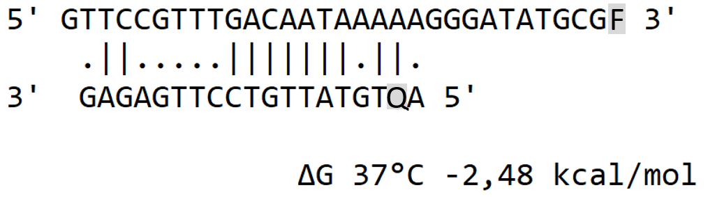

(ref:dimerquench)

Ein weiteres Problem liegt in der erneuten Steigung der Fluoreszenz. Dies würde bedeuten, dass die Zusammenlagerung von Quencher und Fluorophor reversibel und zeitabhänig für einen kurzen Zeitraum stattfindet. Des Weiteren wurde das Ditching innerhalb der Optimierung bei der Reaktionstemperatur, Mischzeitpunkt und Primer-Konzentration beobachtet (siehe Kapitel @ref(infboptimierung)). Interessant ist dabei, dass es nur bei den optimalen Parametern, sprich bei der besten Amplifikation, beobachtet wurde. Gerade die eingeführte Primerasymmetrie führt, wie in Kapitel @ref(dissprimerass) erklärt, dazu, dass mehr Sonde gespalten wird. Eine Erhöhung der Temperatur führt generell zu einer besseren Enzymkinetik [@Jaeger2018], somit ebenfalls zu einer schnelleren Amplifikation und dementsprechend zu einer erhöhten Spaltung der Sonde. Der zusätzliche Mischschritt beschleunigt durch die Homogenisierung ebenfalls die Reaktion und führt wie die anderen Parameter zu einer schnelleren Sondenspaltung. Dementsprechend scheint es einen Zusammenhang zwischen der Menge der gespaltenen Sonde und Ditching zu geben. Jedoch müsste dies in weiteren Experimenten bestätigt werden und generell die Faktoren, welche das Ditching beeinflussen genauer untersucht werden. Ebenfalls stellt die Zusammenlagerung des Fluorophors und Qucheners nur eine Hypothese für das beobachtete Phänomen dar. Der genaue physikalische und molekulare Mechanismus bleibt weiterhin unbekannt und müsste weiter untersucht werden.

## Automatische Auswertung der Amplifikationen mittels Statistik

# Zusammenfassung und Ausblick

[^1]: https://www.promega.de/resources/tools/biomath/tm-calculator/